# Aula12-11

Alex

2024-11-12

## Análise de séries temporais

Foi realizada uma busca pelo termo “protetor solar” no Google Trends.

```
##      Jan Feb Mar Apr May Jun Jul Aug Sep Oct Nov Dec
## 2019  50  31  24  22  22  22  28  29  36  41  39  44
## 2020  42  32  20  18  24  26  32  33  43  42  43  43
## 2021  45  38  29  31  27  28  34  38  48  38  52  50
## 2022  55  51  48  39  37  35  46  50  66  59  73  70
## 2023  79  71  63  55  52  51  59  66  89  70  99 100
## 2024  90  70  65  53  54  52  56  63  71  65  66
```

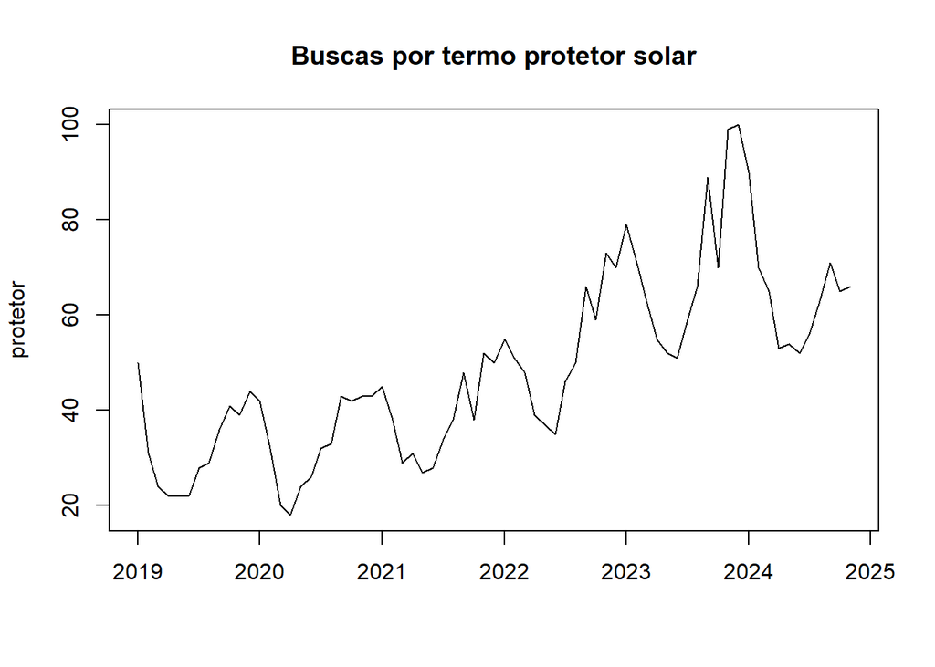

Os dados já foram importados e a série aparece no gráfico com a sazonalidade bem definida e a tendência de buscas aparenta ser crescente.

O próximo passo é identificar as componentes da série.

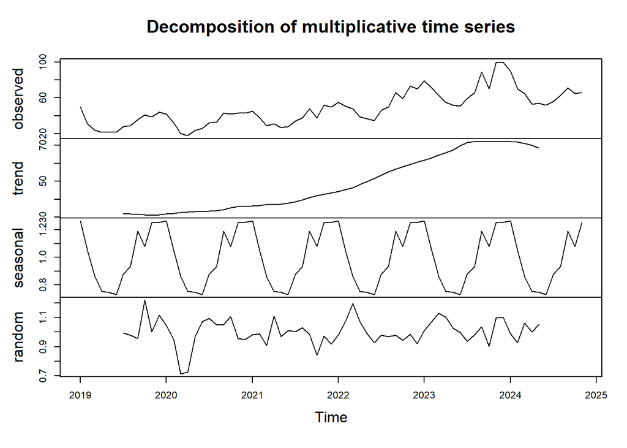

```
##  [1] 1.26 1.05 0.86 0.76 0.75 0.73 0.88 0.93 1.19 1.08 1.25 1.25
```

```
## [1] 12
```

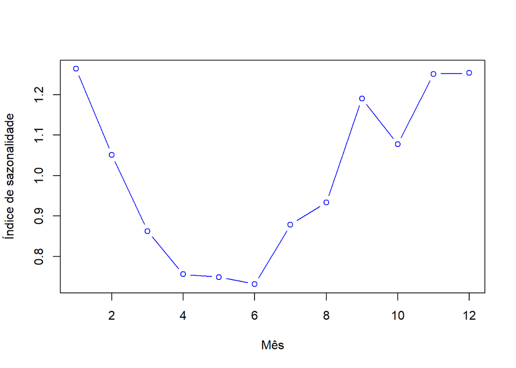

O gráfico da decomposição mostra as componentes de tendência (obtida via a técnica de médias móveis), a sazonalidade e a componente aleatória.

A soma dos índices de sazonalidade precisa ser igual a quantidade de observações que forma um período. Aqui, a soma precisa ser igual a 12 (sum(decomp$figure)).

O gráfico do índice de sazonalidade mostra quando as buscas estão acima ou abaixo da média. A referência é o valor 1. Acima de 1, teremos buscas acima da média dos últimos 12 meses e abaixo de 1, teremos buscas abaixo da média dos últimos 12 meses.

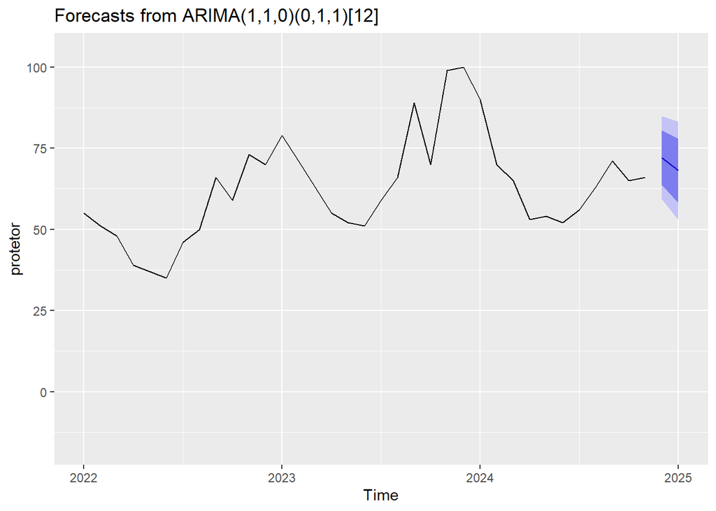

Valores previstos

|  | Point Forecast | Lo 80 | Hi 80 | Lo 95 | Hi 95 |
| --- | --- | --- | --- | --- | --- |
| Dec 2024 | 72.06 | 63.7395 | 80.37 | 59.3371 | 84.77 |
| Jan 2025 | 68.06 | 58.1078 | 78.01 | 52.8404 | 83.28 |
| Feb 2025 | 55.18 | 43.3244 | 67.03 | 37.0502 | 73.30 |
| Mar 2025 | 48.83 | 35.5027 | 62.17 | 28.4452 | 69.22 |
| Apr 2025 | 39.91 | 25.1990 | 54.62 | 17.4113 | 62.41 |
| May 2025 | 39.31 | 23.3580 | 55.27 | 14.9111 | 63.72 |
| Jun 2025 | 37.99 | 20.8687 | 55.10 | 11.8078 | 64.16 |
| Jul 2025 | 44.15 | 25.9535 | 62.36 | 16.3185 | 71.99 |
| Aug 2025 | 50.18 | 30.9517 | 69.40 | 20.7746 | 79.58 |
| Sep 2025 | 63.16 | 42.9594 | 83.35 | 32.2679 | 94.04 |
| Oct 2025 | 53.98 | 32.8509 | 75.10 | 21.6685 | 86.28 |
| Nov 2025 | 64.48 | 42.4713 | 86.50 | 30.8187 | 98.15 |
| Dec 2025 | 67.28 | 42.9975 | 91.56 | 30.1445 | 104.41 |
| Jan 2026 | 64.40 | 38.5543 | 90.24 | 24.8731 | 103.92 |
| Feb 2026 | 51.13 | 23.6575 | 78.61 | 9.1126 | 93.15 |
| Mar 2026 | 44.92 | 15.9592 | 73.89 | 0.6266 | 89.22 |
| Apr 2026 | 35.95 | 5.5575 | 66.35 | -10.5332 | 82.44 |
| May 2026 | 35.37 | 3.6154 | 67.13 | -13.1963 | 83.94 |
| Jun 2026 | 34.04 | 0.9728 | 67.10 | -16.5312 | 84.61 |

O primeiro passo para a modelagem é aprender como os dados se comportaram no passado com a função auto.arima (ARIMA = autoregressive integrated moving average).

As previsões apresentam três cenários: o realista (Point Forecast), o pessimista (Lo 80 e o Lo 95) e o otmista (Hi 80 e o Hi 95).

Para os cenários pessimistas e otimistas são apresentadas duas abordagens: uma com 80% de confiança e outra com 95% de confiança.